# Лекция 8. Event study по индивидуальным событиям

Блок 2. Панель RLMS

Карен Аванесян

Каузальный анализ в R на данных RLMS-HSE

# Зачем

## От «до/после» к траектории

FE (лекция 7) даёт одно число: средний сдвиг исхода, когда $D$ меняется. Но:

динамика

### Нарастает или затухает

Эффект может **нарастать** или **затухать** — одно число это скрывает

предтренд

### Изменения до события

Исход может меняться **до** события — тогда «эффект» был трендом ещё до воздействия

политика

### Вопрос про время

Через сколько лет матери возвращаются на рынок труда?

**Event study** — регрессия исхода на набор индикаторов «$k$ лет до/после события». Коэффициенты рисуют траекторию относительно базового года; годы *до* события — встроенная проверка допущений.

## Пример занятия: child penalty

4 141 матерей: окно −5…+10 лет от первого рождения

3 618 отцов в том же окне

20–60 % долгосрочный штраф для женщин у Kleven et al.

Kleven, Landais, Søgaard 2019

### Штраф за материнство

Рождение первого ребёнка снижает заработки женщин на 20–60 % в долгую, у мужчин — не меняет ничего. Это объясняет большую часть гендерного разрыва

RLMS

### Повторяем дизайн для России

Год рождения первого ребёнка — из ростера домохозяйства (лекция 0). Исходы: занятость, заработок (с нулями у незанятых), часы

```r
ev |> group_by(sex) |> summarise(человек = n_distinct(idind), наблюдений = n(),
                                   `возраст при рождении` = mean(age_at_birth))
```

| sex | человек | наблюдений | возраст при рождении |
| --- | --- | --- | --- |
| Мужчины | 3618 | 22452 | 28.0 |
| Женщины | 4141 | 25453 | 25.2 |

## План занятия

1. Спецификация: индикаторы событийного времени, базовый период, биннинг
2. Child penalty для женщин и мужчин
3. Как читать: предтренды, антиципация, долгосрочный эффект
4. Та же техника для брака (мужчины) и потери работы
5. Что event study не умеет

# Идея

## Спецификация

Для человека $i$, события в году $E_i$ и календарного года $t$, событийное время $k = t - E_i$:

$$y_{it} = \sum_{k \neq -1} \alpha_k \, \mathbb{1}[t - E_i = k] + \lambda_t + \delta_{\text{age}} + \varepsilon_{it}$$

- $\alpha_k$ — разница исхода в год $k$ относительно года **перед** событием ($k = -1$, базовый)
- $\lambda_t$ — год, $\delta_{\text{age}}$ — возраст: отделяем событие от карьерного профиля и календарных шоков; с индивидуальными FE один из них убираем (коллинеарны внутри человека)
- Kleven et al. выражают $\alpha_k$ в долях контрфактического уровня: $P_k = \alpha_k / E[\tilde y_{it} \mid k]$

## Что должно быть верно

| Допущение | Проверка |
| --- | --- |
| **Нет антиципации**: до события исход не реагирует | коэффициенты при $k < -1$ ≈ 0 |
| **Параллельные тренды**: без события траектория продолжилась бы как «до» | те же предкоэффициенты + правдоподобие |
| **Нет отбора по времени события** (беременность не планируют под карьерный провал) | тест: событие не предсказывается прошлыми изменениями исхода |
| **Общая динамика** одинакова для ранних и поздних «когорт» событий | гетерогенность по когортам (лекция 10) |

Плоские предтренды — необходимое, но не достаточное условие. Их отсутствие — почти всегда приговор.

## Биннинг концов

- Для каждого $k$ нужны люди, наблюдаемые ровно в этот год. Крайние $k$ держатся на единицах → шумные коэффициенты
- Решение: **собрать** хвосты в бины: «$\le -5$», «$\ge +10$». Коэффициент бина — среднее по хвосту
- Без биннинга и с несбалансированной панелью крайние точки рисуют «эффекты», которых нет
- Эталон: показывать окно, где **каждый** $k$ опирается на достаточно наблюдений, и честно отмечать, что хвосты — бины

# Код

## Занятость женщин вокруг первого рождения

```r
es_w <- feols(employed ~ i(et, ref = -1) | year + age, data = women, cluster = ~idind)
coeftable(es_w)[1:6, ] |> round(3)
```

```
       Estimate Std. Error t value Pr(>|t|)
et::-5   -0.021      0.022  -0.948    0.343
et::-4    0.037      0.019   1.927    0.054
et::-3    0.033      0.017   1.982    0.048
et::-2    0.047      0.013   3.509    0.000
et::0    -0.118      0.011 -10.491    0.000
et::1    -0.164      0.012 -13.355    0.000
```

`i(et, ref = -1)` создаёт индикатор для каждого значения `et`, кроме базового. Выпишем все на графике:

## График event study

```r
iplot(es_w, main = "Занятость женщин: отклонение от года перед первым рождением",
      xlab = "лет от рождения первого ребёнка", ylab = "доля занятых относительно года −1",
      col = pal["indigo"], ci.lty = 1, ci.width = 0)
```

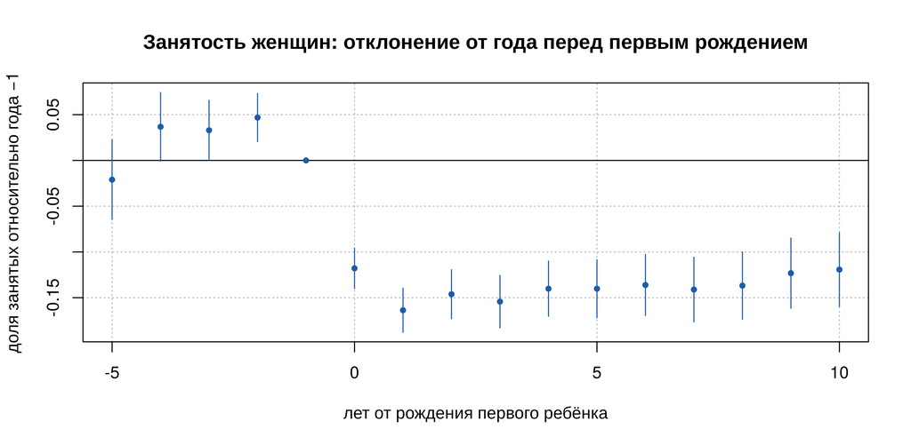

## Как читать вывод `feols()` с `i()`

- Вывод R
- С пояснениями

```r
summary(es_w)
wald(es_w, keep = "et::-")              # H0: все коэффициенты до события = 0
```

```
OLS estimation, Dep. Var.: employed
Observations: 25,451
Fixed-effects: year: 26,  age: 35
Standard-errors: Clustered (idind)
       Estimate Std. Error t value              Pr(>|t|)
et::-5  -0.0210     0.0221  -0.948 0.3429747645224324737
et::-4   0.0368     0.0191   1.927 0.0540928279822685196 .
et::-3   0.0330     0.0166   1.982 0.0475997029237055086 *
et::-2   0.0468     0.0133   3.509 0.0004554216046852899 ***
et::0   -0.1179     0.0112 -10.491             < 2.2e-16 ***
et::1   -0.1637     0.0123 -13.355             < 2.2e-16 ***
et::2   -0.1462     0.0136 -10.714             < 2.2e-16 ***
   …
et::10  -0.1193     0.0206  -5.787 0.0000000076806626613 ***
RMSE: 0.425652     Adj. R2: 0.096865
                 Within R2: 0.015154
```

```
Wald test, H0: joint nullity of et::-5, et::-4, et::-3 and et::-2
 stat = 5.26135, p-value = 3.171e-4, on 4 and 4,139 DoF, VCOV: Clustered (idind).
```

1 · шапка

**Fixed-effects: year, age** — сравниваем женщин одного возраста в одном году. Ошибки — **Clustered (idind)**: 4 140 женщин

2 · строки `et::k`

Занятость через $k$ лет после рождения **относительно года −1**, в долях: `et::1` = -0.164 → на 16 п.п. ниже

3 · нет `et::-1`

Базовый год (`ref = -1`): коэффициент 0 по построению. На `iplot()` — точка на нуле без интервала. Все числа — разницы с ним

4 · `et::-5` … `et::-2`

Предкоэффициенты: была ли разница **до** события. Смотрим на них вместе, а не по звёздочкам каждого

5 · Wald test

$H_0$: все предкоэффициенты = 0. **stat** — F, 4 и 4 139 степеней свободы (G − 1). p = 0.00032. От выбора базового года тест не зависит

6 · сигналы беды

Здесь тест **отвергает**: в годы −4…−2 занятость на 3–5 п.п. выше, чем в −1. Базовый год, вероятно, уже затронут беременностью — антиципация. Сменить базу и сообщить

## Как писать результат

шаблон

«По сравнению с годом, предшествующим рождению первого ребёнка, занятость матерей через год после рождения ниже на **16.4 п.п.** (95 % ДИ от 14.0 до 18.8) и через 5–10 лет остаётся ниже в среднем на 13.3 п.п. (event study с фиксированными эффектами года и возраста, ошибки кластеризованы по женщинам, 25 451 наблюдений). Предкоэффициенты совместно отличны от нуля (F = 5.26, p = 0.00032): занятость снижается уже в год −1; с базовым годом −3 падение через год после рождения — 19.7 п.п.»

- Обязательно: базовый год, контрольные эффекты, тип ошибок, совместный тест предтрендов — и что он показал
- Не писать «предтрендов нет», глядя на отдельные звёздочки; не прятать отвергнутый тест — показать, как меняется оценка при другой базе

## Женщины и мужчины на одном графике

```r
es_m <- feols(employed ~ i(et, ref = -1) | year + age, data = men, cluster = ~idind)
iplot(list(women = es_w, men = es_m), main = "Занятость: матери против отцов",
      xlab = "лет от рождения первого ребёнка", ylab = "доля занятых относительно года −1",
      col = c(pal["coral"], pal["indigo"]), pt.join = TRUE, ci.width = 0)
legend("bottomleft", legend = c("женщины", "мужчины"), col = c(pal["coral"], pal["indigo"]),
       pch = 16, lty = 1, bty = "n")
```

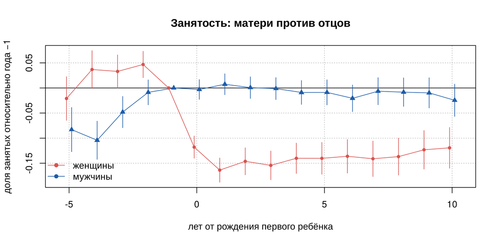

## Заработок с нулями: главный исход Kleven

- Результат
- Код

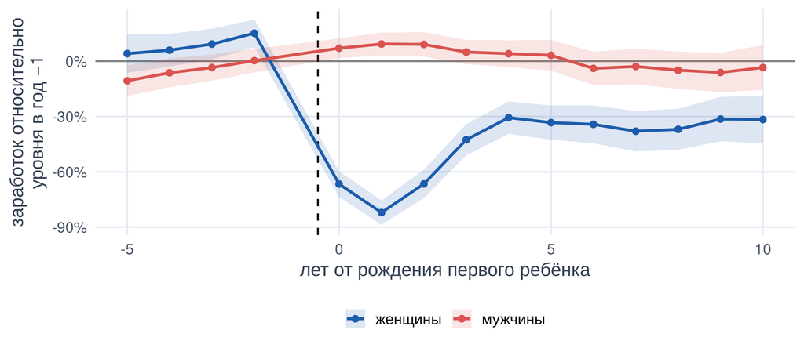

```r
es_earn <- list(
  женщины = feols(earn ~ i(et, ref = -1) | year + age, data = women, cluster = ~idind),
  мужчины = feols(earn ~ i(et, ref = -1) | year + age, data = men,   cluster = ~idind))
base_w <- mean(women$earn[women$et == -1]); base_m <- mean(men$earn[men$et == -1])
pen <- imap_dfr(es_earn, ~ tidy(.x, conf.int = TRUE) |>
                  mutate(k = as.numeric(str_remove(term, "et::")), пол = .y)) |>
  mutate(base = ifelse(пол == "женщины", base_w, base_m),
         across(c(estimate, conf.low, conf.high), ~ .x / base))

ggplot(pen, aes(k, estimate, colour = пол)) +
  geom_hline(yintercept = 0, colour = "grey50") + geom_vline(xintercept = -0.5, linetype = 2) +
  geom_ribbon(aes(ymin = conf.low, ymax = conf.high, fill = пол), alpha = 0.15, colour = NA) +
  geom_line(linewidth = 1.1) + geom_point(size = 2) +
  scale_y_continuous(labels = scales::label_percent()) +
  labs(x = "лет от рождения первого ребёнка", y = "заработок относительно\nуровня в год −1",
       colour = NULL, fill = NULL)
```

## Долгосрочный штраф

```r
pen |> filter(k >= 5) |> group_by(пол) |>
  summarise(`средний эффект, годы 5–10` = mean(estimate)) |>
  mutate(`штраф (разрыв между полами)` = `средний эффект, годы 5–10` -
           `средний эффект, годы 5–10`[пол == "мужчины"])
```

| пол | средний эффект, годы 5–10 | штраф (разрыв между полами) |
| --- | --- | --- |
| женщины | -0.343 | -0.312 |
| мужчины | -0.030 | 0.000 |

## Биннинг: что меняется на краях

```r
women_long <- rlms |>
  filter(female == 1, !is.na(first_birth_year), first_birth_year >= 2002, first_birth_year <= 2022,
         age >= 18, age <= 55) |>
  mutate(et = year - first_birth_year, et_b = pmin(pmax(et, -5), 10))   # бины: ≤ −5 и ≥ 10
es_raw <- feols(employed ~ i(et, ref = -1) | year + age, data = women_long, cluster = ~idind)
es_bin <- feols(employed ~ i(et_b, ref = -1) | year + age, data = women_long, cluster = ~idind)
women_long |> count(et) |> filter(et %in% c(-12, -9, -6, -5, 10, 13, 16, 20)) |>
  mutate(`без биннинга` = coef(es_raw)[paste0("et::", et)],
         `бин` = coef(es_bin)[paste0("et_b::", pmin(pmax(et, -5), 10))]) |>
  mutate(across(where(is.numeric), ~ round(.x, 3)))
```

## Биннинг: что меняется на краях

| et | n | без биннинга | бин |
| --- | --- | --- | --- |
| -12 | 43 | -0.053 | -0.022 |
| -9 | 125 | -0.083 | -0.022 |
| -6 | 346 | -0.003 | -0.022 |
| -5 | 463 | -0.025 | -0.022 |
| 10 | 1793 | -0.120 | -0.101 |
| 13 | 1398 | -0.097 | -0.101 |
| 16 | 992 | -0.076 | -0.101 |
| 20 | 463 | -0.049 | -0.101 |

## Чтение таблицы биннинга

- Слева от окна наблюдений мало ($k = -12$: 43 наблюдения); справа — особая выборка: те, кого RLMS видит 15–20 лет после рождения, — родившие рано и не выбывшие из панели
- Бин усредняет хвост одним коэффициентом вместо десятка шумных; внутри окна −5…+10 коэффициенты не меняются
- Правило: окно — там, где на каждый $k$ есть сотни наблюдений и состав выборки не дрейфует

## Та же техника: брак у мужчин

В лекции 7 FE дал премию за брак 5 %. Что происходит с зарплатой **вокруг** свадьбы?

- Результат
- Код

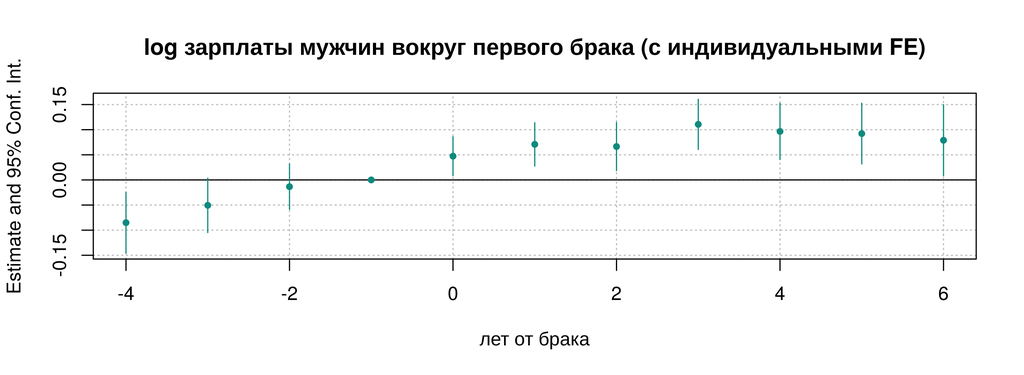

```r
mar <- rlms |> filter(female == 0, age >= 20, age <= 50, !is.na(married)) |>
  arrange(idind, year) |> group_by(idind) |>
  mutate(was_single = lag(cumany(married == 0), default = FALSE),        # уже видели холостым
         first_mar = ifelse(married == 1 & was_single, year, NA),
         mar_year = suppressWarnings(min(first_mar, na.rm = TRUE))) |> ungroup() |>
  filter(is.finite(mar_year), employed == 1, !is.na(log_wage)) |>
  mutate(et = pmin(pmax(year - mar_year, -4), 6))
es_mar <- feols(log_wage ~ i(et, ref = -1) | idind + year, data = mar, cluster = ~idind)
iplot(es_mar, main = "log зарплаты мужчин вокруг первого брака (с индивидуальными FE)",
      xlab = "лет от брака", col = pal["teal"], ci.width = 0)
```

## Чтение графика брака

- Зарплата растёт **до** брака: часть «премии» из FE — это тренд, на котором женятся, а не следствие брака
- После брака траектория продолжается без скачка → event study делает FE-оценку скромнее
- Общий вывод для любого «воздействия, которое люди выбирают сами»: сначала посмотрите, что происходило **до**

## Потеря работы и здоровье

- Результат
- Код

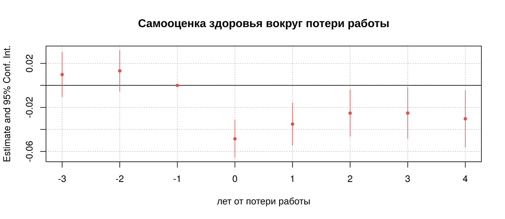

```r
job <- rlms |> filter(age >= 25, age <= 55, !is.na(health_score)) |>
  arrange(idind, year) |> group_by(idind) |>
  mutate(lost = employed == 0 & lag(employed) == 1 & lag(year) == year - 1,
         loss_year = suppressWarnings(min(year[lost], na.rm = TRUE))) |> ungroup() |>
  filter(is.finite(loss_year)) |>
  mutate(et = pmin(pmax(year - loss_year, -3), 4))
es_job <- feols(health_score ~ i(et, ref = -1) | idind + year, data = job, cluster = ~idind)
iplot(es_job, main = "Самооценка здоровья вокруг потери работы", xlab = "лет от потери работы",
      col = pal["coral"], ci.width = 0)
```

# Как ошибаются

## Шесть ошибок с event study

1. Нет базового периода или базовый — последний год (тогда предтренды рисуются относительно «после»)
2. Крайние $k$ без биннинга, на десятках наблюдений, — и выводы по ним
3. Предтренд есть, но «мы учитываем это линейным трендом» — без обоснования
4. Событие выбирается самим человеком, а порядок «исход → событие» не проверен
5. Разные события (ранние/поздние когорты) с разной динамикой свалены в один TWFE — лекция 10
6. Нет контрольной группы «без события», а эффект объявлен абсолютным, а не относительным к $k = -1$

## Чек-лист

- Событие определено по данным однозначно (первый год, когда …), с датой
- Окно и биннинг объявлены; показано число наблюдений на каждый $k$
- Базовый период $k = -1$; возраст и год (или индивидуальные FE) учтены
- Предкоэффициенты показаны и обсуждены
- Эффект переведён в проценты от контрфактического уровня
- Кластер по человеку

# Мини-задача

## Задание к следующему занятию

1. Постройте child penalty по **часам работы** (`hours`) и по **официальному оформлению** среди занятых. Где штраф больше?
2. Разбейте женщин по образованию (высшее / нет) и постройте два графика. У кого штраф глубже и дольше? Предложите два объяснения
3. Повторите event study брака для **женщин**. Есть ли предтренд? Что происходит после?
4. Для события «выход на пенсию» (`pension` переходит 0 → 1) постройте траекторию занятости и самооценки здоровья. Нужна ли здесь группа сравнения — и какая?

# Литература

## Что прочитать

- Kleven H., Landais C., Søgaard J. (2019). Children and Gender Inequality: Evidence from Denmark. *AEJ: Applied* — исходный дизайн
- Kleven H. et al. (2019). Child Penalties across Countries. *AEA P&P* — сравнение стран
- Miller D., Johnson S., Shenhav N. (2023). Confronting Selection in Event Studies — отбор по времени события
- Huntington-Klein N. *The Effect*, гл. 17 «Event Studies»
- Schmidheiny K., Siegloch S. (2023). On Event Studies and Distributed-Lag Models. *J. Applied Econometrics* — биннинг и нормализация
- `fixest`: [виньетка про `i()` и `iplot()`](https://lrberge.github.io/fixest/articles/fixest_walkthrough.html)

Каузальный анализ в R · RLMS-HSE · К. Аванесян

← К программе курса